# working_recognition_final

```python
import pandas as pd
import numpy as np
import matplotlib.pyplot as plt
```

```python
df=pd.read_csv('case2_작업분류.csv')
```

```python
total_df=pd.read_excel('case2_전체데이터.xlsx')
```

```python
total_df.head()
```

|  | frame | X1 | Y1 | Z1 | X2 | Y2 | Z2 | X3 | Y3 | Z3 | ... | Z5 | X6 | Y6 | Z6 | X7 | Y7 | Z7 | BEulerX | BEulerY | BEulerZ |
| --- | --- | --- | --- | --- | --- | --- | --- | --- | --- | --- | --- | --- | --- | --- | --- | --- | --- | --- | --- | --- | --- |
| 0 | 1 | -0.458004 | -0.301012 | 0.069851 | -21.4986 | 16.6164 | -46.5252 | -20.8596 | 25.6374 | -7.57549 | ... | -43.8590 | -39.8291 | -4.29553 | -3.40112 | -63.8925 | 12.72660 | 2.18449 | 358.498 | 24.8711 | 3.82188 |
| 1 | 2 | -0.764465 | -0.441665 | 0.110851 | -21.2948 | 16.5634 | -46.6795 | -20.7314 | 25.9445 | -8.05705 | ... | -43.5805 | -37.6161 | -4.82782 | -3.01132 | -62.9538 | 10.31150 | 2.35541 | 356.856 | 24.8318 | 4.44333 |
| 2 | 3 | -0.937817 | -0.536425 | 0.053772 | -21.1203 | 16.3423 | -46.9332 | -20.5950 | 26.0598 | -8.61051 | ... | -43.3597 | -35.9652 | -5.10691 | -2.62378 | -61.9671 | 8.80078 | 2.89701 | 355.640 | 24.8196 | 5.12549 |
| 3 | 4 | -1.022700 | -0.534820 | 0.138092 | -21.0589 | 16.1583 | -46.9776 | -20.4041 | 26.0608 | -8.76589 | ... | -43.0981 | -35.0784 | -5.35559 | -2.26297 | -61.3468 | 7.93594 | 3.50829 | 355.135 | 24.7971 | 5.56574 |
| 4 | 5 | -1.228900 | -0.590238 | 0.206341 | -21.0387 | 15.9725 | -47.0509 | -20.1903 | 26.0018 | -9.09602 | ... | -42.8411 | -34.2118 | -5.57838 | -1.76118 | -60.3816 | 7.50886 | 4.86214 | 354.376 | 24.7573 | 6.04128 |

5 rows × 25 columns

## get_labeling_df : Labeling 을 해주는 함수

```python
def get_labeling_df(label_df,total_df):
    '''
    * label_df : 작업분류가 되어있는 데이터 frameStart, frameEnd, action 열을 가진다.
    * total_df : 작업자의 frame별 데이터 전체가 들어가 있는 데이터, frame과 모든 센서값들을 가진다.
    total_df의 frame 개수만큼 notworking을 가지고 있다가 frameStart~frameEnd까지 frame의 label을 변경한다.
    '''
    label_list=['notworking']*total_df.shape[0]
    for i in range(label_df.shape[0]):
        for j in range(label_df.frameStart[i]-1,label_df.frameEnd[i]):
            label_list[j]=label_df.action[i]
    return label_list
```

## get_labeling_df 후 label열에 추가해준다.

```python
total_df['label']=get_labeling_df(df,total_df)
```

```python
#total_df.to_excel('labeling_df.xlsx') #labeling_df(라벨링 후 데이터의 저장)
```

## get_sec_df : 프레임을 초단위로 묶어주는 함수

step size가 너무 커지면 터져버리는 현상때문에 구현한 함수인데, 생각보다 성능이 많이 향상되었다.

```python
def get_sec_df(df):
    '''
    * df : labeling까지 완료한 데이터프레임

    30 frame을 1초로 묶는 과정이기 때문에 센서값은 물론 label(action) 또한 어떠한 처리를 통해 1초로 묶어줘야한다.
    센서값들은 30frame 간 평균을 구해 1초로 묶어준다.
    label은 더미화로 변환 후 수를 합쳐 30frame 간 빈도를 합산하고 argmax로 가장 많이나온 행동을 1초간 행동으로 분류한다.
    label까지 마친 데이터프레임에서 불필요한 feature들을 제거하고 인덱스를 초기화한 후 해당 데이터프레임을 반환한다.

    '''
    sec_list=[i//30 for i in df.frame] # frame을 30(1초)로 나눈 몫을 가지는 sec(ond)_list를 만든다.
    df=pd.get_dummies(df)
    df['sec']=sec_list
    df=df.groupby('sec').mean()
    label_list=[np.argmax(i) for i in df[['label_cable','label_cap','label_notworking','label_screw']].values]

    for i,j in enumerate(label_list):
        if j==0:
            label_list[i]='cable'
        elif j==1:
            label_list[i]='cap'
        elif j==2:
            label_list[i]='notworking'
        else:
            label_list[i]='screw'

    df['label']=label_list
    df=df.drop(['label_cable','label_cap','label_notworking','label_screw'],axis=1)
    df=df.reset_index()
    return df
```

```python
sec_df=get_sec_df(total_df) # sec_df는 초 단위로 묶은 데이터이다.
```

```python
sec_df.head()
```

|  | sec | frame | X1 | Y1 | Z1 | X2 | Y2 | Z2 | X3 | Y3 | ... | X6 | Y6 | Z6 | X7 | Y7 | Z7 | BEulerX | BEulerY | BEulerZ | label |
| --- | --- | --- | --- | --- | --- | --- | --- | --- | --- | --- | --- | --- | --- | --- | --- | --- | --- | --- | --- | --- | --- |
| 0 | 0 | 15.0 | -2.248395 | -0.913317 | -0.156844 | -22.752521 | 16.506738 | -46.783028 | -20.814421 | 26.112645 | ... | -36.611503 | -5.545910 | -1.201237 | -59.056186 | 12.762071 | 5.617275 | 354.092379 | 25.805759 | 5.213154 | notworking |
| 1 | 1 | 44.5 | -2.633518 | 0.828645 | -1.185001 | -26.921007 | 17.527140 | -46.187827 | -24.852127 | 25.932520 | ... | -40.035877 | -3.935279 | -2.057942 | -62.394260 | 15.379442 | 2.552773 | 214.440501 | 29.094583 | 4.128861 | notworking |
| 2 | 2 | 74.5 | -3.465110 | -2.699092 | -3.180691 | -33.499177 | 7.590184 | -46.515700 | -39.139620 | 17.701000 | ... | -23.231973 | -22.514890 | -16.863663 | -47.104307 | -15.890146 | -1.828313 | 12.846927 | 32.222360 | 3.325306 | notworking |
| 3 | 3 | 104.5 | -7.407463 | -2.740310 | -10.684942 | -46.002040 | -6.478829 | -47.498013 | -61.420453 | 20.897136 | ... | -41.992553 | -27.643260 | -2.299151 | -66.951277 | -17.749681 | 7.268657 | 25.556187 | 46.700087 | 9.446874 | notworking |
| 4 | 4 | 134.5 | -9.459907 | 7.804870 | -6.228626 | -50.081703 | -2.803780 | -39.794487 | -44.546033 | -2.643085 | ... | -21.765724 | -15.653796 | -13.604525 | -32.446227 | -21.304549 | -0.690835 | 52.852777 | 39.600023 | 232.119459 | notworking |

5 rows × 27 columns

## create_dataset : 시계열 처리에 적합한 데이터로 변환해주는 함수

적당한 그림이 없어서 그렸는데 이해가 안되시면 전화주시거나 시계열 처리를 조금 검색해보시면 될 듯 합니다 ㅠ

[figure not shown]

```python
def create_dataset(df, label, step=10):
    '''
    * df : 변환할 데이터프레임
    * label : 변환할 데이터프레임의 라벨

    사용하지 못하는 열과 학습에 의미가 없는 3개 feature를 제거하고 label 별로 stepsize에 맞게 데이터를 묶어서 정렬한다. (그림참고)
    Example
    capping -> 10초씩 묶어서 라벨링 후 저장
    screw -> 10초씩 묶어서 라벨링 후 저장
    '''
    df=df.drop(['BEulerX','BEulerZ','frame'],axis=1)
    x_data = []
    y_data = []
    for i in label.unique():
        tmp_df=df.query('label=="{}"'.format(i)).reset_index()
        for j in range(tmp_df.shape[0] - step):
            x_data.append(tmp_df.drop(['label'],axis=1).iloc[j:j+step].values)
            y_data.append(i)
    return np.array(x_data),np.array(y_data)
```

```python
features,targets=create_dataset(sec_df,sec_df.label)
```

## target이 더미화해서 들어가야 연산이 되기 때문에 더미화를 해주고 적절한 이름을 붙혀준다.

```python
targets=pd.get_dummies(pd.DataFrame(targets))
targets.columns=['cable','cap','notworking','screw']
```

```python
from sklearn.model_selection import train_test_split
```

## train,test 데이터로 나눈다. 이 때 stratify는 반드시 사용하는 것이 좋다.

- stratify = train과 test에 각 행동이 뽑힐 확률을 맞춰준다.
- ex) train=cable(20%),cap(20%),notworking(40%),screw(20%) 이면 테스트 역시 test=cable(20%),cap(20%),notworking(40%),screw(20%)로 구성

```python
X_train, X_test, y_train, y_test = train_test_split(features, targets, stratify=targets, random_state=11)
```

```python
X_train.shape
```

```
(877, 10, 24)
```

```python
from keras.models import Sequential
from keras.layers import Dense
from keras.layers import LSTM
from keras.layers import Dropout
import tensorflow as tf
import keras.backend.tensorflow_backend as K
```

## LSTM MODEL (Hyper parameter)

- step : 위의 stepsize를 조정하면 성능에 영향을 미칠 수 있다.
- 층 추가 : input층과 output층은 고정이며 같은 방식으로 lstm_year3,4 같이 추가할 수 있다.
- dropout 추가 : 그레디언트 손실문제를 막기위해 규제 층인 dropout층을 추가하면 성능향상을 기대할 수는 있으나 현재 모델에서는 크게 도움이 되지 않았다.
- units : node 수, 각 층의 노드 수를 조정해 성능향상을 기대할 수 있다. (outputlayer의 노드 수는 분류할 작업의 종류 + 비작업 수로 고정)
- activation : 활성화 함수로 relu,softmax, sigmoid가 대표적이며 다양한 함수가 있다. (!outputlayer는 분류 문제의 경우 softmax로 고정하는 것이 좋다.)
- optimizer : 옵티마이져를 통해서도 성능향상을 기대할 수 있다. (sgd, rmsprop 등)
- epochs : 반복 횟수를 조정하면 성능향상을 기대할 수 있다. (너무 높힐 시 오버피팅의 위험이 있다.)
- batch_size : 반복 횟수 1회당 몇 개의 데이터를 학습할 것인가이며 작은 크기를 주면 세세하게 학습을 하여 성능향상을 기대할 수 있지만 러닝타임이 엄청나게 증가한다.

```python
def create_model(optim, loss):
    model = Sequential()

    model.add(LSTM(units = 50, return_sequences = True, input_shape = (X_train.shape[1], X_train.shape[2]), name='lstm_year1'))
    #model.add(Dropout(0.2, name='dropout1')) #dropout 층

    model.add(LSTM(units = 30, activation='relu',name='lstm_year2'))

    model.add(Dense(units = 4, activation='softmax', name='output_layer'))

    model.compile(optimizer = optim, loss = loss,metrics=['accuracy'])

    return model
```

```python
clf = create_model('adam', 'categorical_crossentropy') # adam = optimizer
clf.summary()
```

```
_________________________________________________________________
Layer (type)                 Output Shape              Param #
=================================================================
lstm_year1 (LSTM)            (None, 10, 50)            15000
_________________________________________________________________
lstm_year2 (LSTM)            (None, 30)                9720
_________________________________________________________________
output_layer (Dense)         (None, 4)                 124
=================================================================
Total params: 24,844
Trainable params: 24,844
Non-trainable params: 0
_________________________________________________________________
```

```python
history=clf.fit(X_train, y_train, epochs = 30, batch_size = 32, shuffle=False)
```

## epoch별 train 데이터의 정확도를 확인한다.

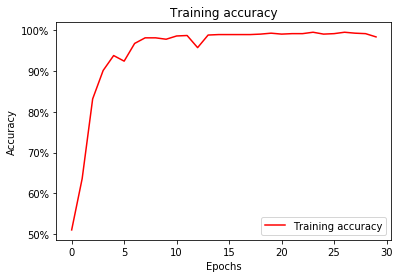

```python
import matplotlib.pyplot as plt
%matplotlib inline
history_dict = history.history
acc_values = history_dict['acc']
epochs = range(30)


plt.plot(epochs, history.history['acc'], 'r', label='Training accuracy')
plt.title('Training accuracy')
plt.xlabel('Epochs')
plt.ylabel('Accuracy')
plt.gca().set_yticklabels(['{:.0f}%'.format(x*100) for x in plt.gca().get_yticks()])
plt.legend()
plt.grid('off')
plt.show()
```

## 학습한 적이 없는 test 데이터로 acc를 확인할 수 있는 함수이다. (최종성능)

```python
def get_acc(pred):
    '''
    *pred : 학습한 clf 모델의 예측값을 넣어준다.
    예측값과 실제값을 비교하여 맞는 개수를 세어 전체 개수에 나눠준다.
    '''
    acc_score=0
    for i in range(pred.shape[0]):
        try:
            if np.argmax(pred[i])==np.argmax(y_test.values[i]):
                acc_score+=1
        except IndexError :
            continue
    acc=acc_score/pred.shape[0]
    return acc
```

```python
get_acc(clf.predict(X_test))
```

```
0.9522184300341296
```